# Lab 4: Data is Delicious

Author

Diya Patel

GitHub Link: https://github.com/diyapatel040124/GSB-544-Computing-and-Machine-Learning/blob/main/Lab%204.html

```python
!pip install beautifulsoup4
```

```python
import pandas as pd
import requests
from bs4 import BeautifulSoup
from urllib.parse import urljoin
import re
```

Read in the HTML from the URL using the requests library

```python
url = "https://tastesbetterfromscratch.com/meal-plan-192/"
HEADERS = {"User-Agent": "Mozilla/5.0 (Windows NT 10.0; Win64;x64)"}
response = requests.get(url, headers=HEADERS)
```

Use Beautiful Soup to parse this string into a tree called soup

```python
soup=BeautifulSoup(response.content, 'html.parser')
```

To find an HTML tag corresponding to a specific element on a webpage, right-click on it and choose, “inspect”. Go to the meal prep days to do this.

```python
# find all p tags (<p>) that have the class "has-text-align-left"
rows = soup.find_all("p", class_="has-text-align-left")

# create an empty list for for table columns
days = []
names = []
links = []
prices = []

# created a for loop to go through each paragraph with the p tags
for p in rows:
    day_tag = p.find("strong") # the tag that holds the day of the week
    link_tag = p.find("a") # the tag that holds the recipe link

    #Only day and recipe rows
    if not (day_tag and link_tag):
        continue

    # get the text of the day and remove the colon
    day = day_tag.get_text(strip=True).rstrip(":")
    # recipe name is stored in the link tag
    name = link_tag.get_text(strip=True)
    # get the link URL from the href attribute
    link = link_tag.get("href", "")


    #Find only the part of the price with the dollar sign (i had to ask ai for some help on how to extract the pricing)
    price = None
    for chunk in p.stripped_strings:
        # if a chunk has the "$" sign, extract the numbers after it
        if "$" in chunk:
            after_dollar = chunk.split("$", 1)[1].strip()
            # only want digits included with the decimal point for the price
            price = "".join(ch for ch in after_dollar if (ch.isdigit() or ch == "."))
            break
    # add each piece of data to its list
    days.append(day)
    names.append(name)
    links.append(link)
    prices.append(price)

# create a dataframe to get our column headers and info in each
df = pd.DataFrame({
    "Day of the Week": days,
    "Name of Recipe": names,
    "Link to Recipe": links,
    "Price of Recipe": prices
})
df
```

|  | Day of the Week | Name of Recipe | Link to Recipe | Price of Recipe |
| --- | --- | --- | --- | --- |
| 0 | Monday | Pork Carnitas | https://tastesbetterfromscratch.com/slow-cooke... | 17.98 |
| 1 | Tuesday | Honey Mustard Chicken Salad | https://tastesbetterfromscratch.com/crusted-ho... | 12.38 |
| 2 | Wednesday | Garlic Chicken | https://tastesbetterfromscratch.com/chicken-wi... | 11.32 |
| 3 | Thursday | Drunken Noodles | https://tastesbetterfromscratch.com/drunken-no... | 12.67 |
| 4 | Friday | Cottage Pie | https://tastesbetterfromscratch.com/cottage-pie/ | 20.70 |

2. Data from and API Using the Tasty API from the practice activity, search for recipes that match the “Monday” recipe in your meal plan. Compile a table of all these recipes

```python
# after scraping the dataframe, get the Monday recipe names (pork carnitas recipes)
monday_recipe = df.loc[df["Day of the Week"].str.lower() == "monday", "Name of Recipe"].iloc[0]

# lowercase, and remove extra spaces so it can be used as a search term
search_term = monday_recipe.strip().lower()

# URL for the tasty api taken from PA 4.1
url = "https://tasty.p.rapidapi.com/recipes/list"

querystring = {"from":"0","size":"20","q":"q"}

headers = {
    "X-RapidAPI-Key": "c003bcc51amshee6d26f4156657ap163fdajsn574bc5976f00",
    "X-RapidAPI-Host": "tasty.p.rapidapi.com"
}

#only collect 100 results
# make an empty list to collect monday recipes
all_results = []

# loop in increments of 20 to get up to 100 results total. (had to ask ai for help since Positron crashed with the exceeding amount of data)
for start in range(0,100,20):
    # update the query each time with a new starting index and recipe
    querystring = {"from":str(start),"size":"20","q":search_term}
    response = requests.get(url, headers=headers, params=querystring)
    data = response.json()
    # get the list of recipes inside the "results" key
    results = data.get("results", []) # if there are no results, end the loop
    if not results:
        break
    all_results.extend(results) # add the recipes to a series

pork_carnitas_recipes = pd.json_normalize(all_results)
pork_carnitas_recipes["name"]
```

```
0                            Slow Cooker Carnitas
1    Mexican Carnitas As Made By Claudette Zepeda
2                            Instant Pot Carnitas
3                           Carnitas Steamed Buns
4                                  Carnitas Salad
5          Carnitas Tostadas With Pineapple Salsa
6                               Sopes De Carnitas
7                                   Torta Ahogada
8                    Carnitas For the Carnivores!
9                   25 Amazing Dinners From Tasty
Name: name, dtype: object
```

3. Automate it Write a function called get_mealplan_data that performs 2 and 3 above automatically.

Scrape one weekly meal plan

```python
def get_weekly_plan(plan_number):
    # Build the meal plan URL using the plan number (202)
    url = f"https://tastesbetterfromscratch.com/meal-plan-{plan_number}/"
    html = requests.get(url, headers={"User-Agent": "Mozilla/5.0"}).text
    soup = BeautifulSoup(html, "html.parser")

    # create an empty list to collect one dictionary per day and recipe row
    rows = []

    # Pulled from part one
    for p in soup.select("p.has-text-align-left"):
        day_tag = p.find("strong")
        a_tag = p.find("a")
        if not (day_tag and a_tag):
            continue
        day = day_tag.get_text(strip=True).rstrip(":")
        name = a_tag.get_text(strip=True)
        link = urljoin(url, a_tag.get("href", ""))

        #Use regex to pull the price from the paragraph's text
        m = re.search(r"\$([\d.]+)", " ".join(p.stripped_strings))
        price = m.group(1) if m else None

        # save the data all in one row
        rows.append({"Day": day,
                    "Name": name,
                    "Link":link,
                    "Price":price})
    return pd.DataFrame(rows)
```

Get up to 100 matches for a recipe name

```python
def match_recipe(recipe_name, limit=100):
    # create a search term to keep letter/numbers/spaces all lowercases
    q = re.sub(r"[^A-Za-z0-9 ]+", " ", str(recipe_name)).strip().lower()
    # return an empty table if the query is empty
    if not q:
        return pd.DataFrame()

    # pulled from part 2
    url = "https://tasty.p.rapidapi.com/recipes/list"
    headers = {"X-RapidAPI-Key":'c003bcc51amshee6d26f4156657ap163fdajsn574bc5976f00' , "X-RapidAPI-Host": "tasty.p.rapidapi.com"}

    results = []
    for start in range(0, limit, 20):
        r = requests.get(url, headers=headers, params={"from": str(start), "size":"20", "q":q})
        batch = r.json().get("results", []) or []
        if not batch:
            break
        results.extend(batch)
        if len(batch) <20:
            break

    if not results: # return the empty dataframe if there is nothing
        return pd.DataFrame()

    df = pd.json_normalize(results)
    # we want to keep the following columns to reveal more insight about each day's meal plan.
    keep = [c for c in ["id", "name", "num_servings", "total_time_minutes", "nutrition.calories"] if c in df.columns]
    return df[keep]
```

Put two helper functions together to get one meal plan number

```python
import re
def get_mealplan_data(plan_number):
    # scrape the weekly plan table (Day, Name, Link, Price)
    plan = get_weekly_plan(plan_number)

    # holds a dataframe for each day (after matching Tasty recipes)
    out = []
    # for each meal in the plan, search Tasty and attach the returned results
    for _,row in plan.iterrows():
        # search 100 matches for the recipe type
        matches = match_recipe(row["Name"], limit=100)
        # if Tasty returns nothing, create one empty row to still keep the meal
        if matches.empty:
            matches = pd.DataFrame([{
                "id":None,
                "name": None,
                "num_servings":None,
                "total_time_minutes": None,
                "nutrition.calories":None}])

        # Add the meal-plan columns to the left of the Tasty columns (tried using the merge function but table returned empty table with only column headers. i has to ask ai for this part)
        matches.insert(0, "Day", row["Day"])
        matches.insert(1, "Meal", row["Name"])
        matches.insert(2, "Link", row["Link"])
        matches.insert(3, "Price", row["Price"])

        # rename Tasty's anem to 'Tasty Recipe' so we can see both names
        if "name" in matches.columns:
            matches.rename(columns={"name": "Tasty Recipe"}, inplace=True)
        out.append(matches)
    # if nothing was added return an empty dataframe
    if not out:
        print("No recipes found for this meal plan.")
        return pd.DataFrame()
    # using concat function, stack the days together in one final dataframe
    df = pd.concat(out, ignore_index=True)
    # return the columns we want
    columns = ["Day", "Name", "Link", "Price", "id", "Tasty Recipe",
    "num_servings", "total_time_minutes", "nutrition.calories"]

    df = df[[c for c in columns if c in df.columns]]
    return df
```

```python
df = get_mealplan_data(202)
df
```

|  | Day | Link | Price | id | Tasty Recipe | num_servings | total_time_minutes | nutrition.calories |
| --- | --- | --- | --- | --- | --- | --- | --- | --- |
| 0 | Monday | https://tastesbetterfromscratch.com/skinny-chi... | 10.82 | None | None | NaN | NaN | NaN |
| 1 | Tuesday | https://tastesbetterfromscratch.com/beef-noodl... | 29.29 | 3822 | Taiwanese Beef Noodle Soup | 6.0 | 210.0 | 887.0 |
| 2 | Tuesday | https://tastesbetterfromscratch.com/beef-noodl... | 29.29 | 7641 | Classic Lasagna Soup | 4.0 | 35.0 | 697.0 |
| 3 | Tuesday | https://tastesbetterfromscratch.com/beef-noodl... | 29.29 | 3776 | Traditional Vietnamese Beef Pho | 8.0 | 480.0 | 539.0 |
| 4 | Tuesday | https://tastesbetterfromscratch.com/beef-noodl... | 29.29 | 5464 | 1-Day Noodles (Taiwanese Beef Noodle Soup) | 8.0 | 0.0 | NaN |
| ... | ... | ... | ... | ... | ... | ... | ... | ... |
| 117 | Friday | https://tastesbetterfromscratch.com/chicken-gy... | 21.22 | 642 | 5 Fork-less Finger Foods | NaN | NaN | NaN |
| 118 | Friday | https://tastesbetterfromscratch.com/chicken-gy... | 21.22 | 2239 | Homemade American Street Foods | NaN | NaN | NaN |
| 119 | Friday | https://tastesbetterfromscratch.com/chicken-gy... | 21.22 | 2463 | Chicken Recipes For The Whole Month | NaN | NaN | NaN |
| 120 | Friday | https://tastesbetterfromscratch.com/chicken-gy... | 21.22 | 3370 | Tasty Dinners for Every Night of December | NaN | NaN | NaN |
| 121 | Friday | https://tastesbetterfromscratch.com/chicken-gy... | 21.22 | 1368 | 11 Street Food Recipes You Can Make At Home | NaN | NaN | NaN |

122 rows × 8 columns

Scrape the weekly meal plan, search the Tasty API for each meal and combine everything into one whole Dataframe with your meal-plan info plus Tasty matches

4. Add a column with fuzzy matching Add a column to your df dataset indicating whether the recipe in that row is vegetarian or not

```python
import re
# if the column is called "Meal" (from part 3), rename it so we can use the same name later
if "Meal" in df.columns:
    df.rename(columns={"Meal": "Name of Recipe"}, inplace=True)

# if the table has "Tasty Recipe" from the API, use that column name instead
if "Tasty Recipe" in df.columns:
    name_column = "Tasty Recipe"
else:
    name_column = "Name of Recipe"

# create a vocabulary list of meat words to look for in recipe titles
meat_words = ["chicken", "beef", "pork", "fish", "shells", "bacon", "turkey", "ham" "lamb", "duck", "crab", "tuna"]

# make a pattern that looks for any of the meat words
pattern = re.compile("|".join(meat_words), re.IGNORECASE)

# create a new column called "Vegetarian"
# this will have have True/False outputs
df["Vegetarian"] = ~df[name_column].fillna("").str.contains(pattern) # return True if name column does not contain meat words (~)
```

```python
df
```

|  | Day | Link | Price | id | Tasty Recipe | num_servings | total_time_minutes | nutrition.calories | Vegetarian |
| --- | --- | --- | --- | --- | --- | --- | --- | --- | --- |
| 0 | Monday | https://tastesbetterfromscratch.com/skinny-chi... | 10.82 | None | None | NaN | NaN | NaN | True |
| 1 | Tuesday | https://tastesbetterfromscratch.com/beef-noodl... | 29.29 | 3822 | Taiwanese Beef Noodle Soup | 6.0 | 210.0 | 887.0 | False |
| 2 | Tuesday | https://tastesbetterfromscratch.com/beef-noodl... | 29.29 | 7641 | Classic Lasagna Soup | 4.0 | 35.0 | 697.0 | True |
| 3 | Tuesday | https://tastesbetterfromscratch.com/beef-noodl... | 29.29 | 3776 | Traditional Vietnamese Beef Pho | 8.0 | 480.0 | 539.0 | False |
| 4 | Tuesday | https://tastesbetterfromscratch.com/beef-noodl... | 29.29 | 5464 | 1-Day Noodles (Taiwanese Beef Noodle Soup) | 8.0 | 0.0 | NaN | False |
| ... | ... | ... | ... | ... | ... | ... | ... | ... | ... |
| 117 | Friday | https://tastesbetterfromscratch.com/chicken-gy... | 21.22 | 642 | 5 Fork-less Finger Foods | NaN | NaN | NaN | True |
| 118 | Friday | https://tastesbetterfromscratch.com/chicken-gy... | 21.22 | 2239 | Homemade American Street Foods | NaN | NaN | NaN | True |
| 119 | Friday | https://tastesbetterfromscratch.com/chicken-gy... | 21.22 | 2463 | Chicken Recipes For The Whole Month | NaN | NaN | NaN | False |
| 120 | Friday | https://tastesbetterfromscratch.com/chicken-gy... | 21.22 | 3370 | Tasty Dinners for Every Night of December | NaN | NaN | NaN | True |
| 121 | Friday | https://tastesbetterfromscratch.com/chicken-gy... | 21.22 | 1368 | 11 Street Food Recipes You Can Make At Home | NaN | NaN | NaN | True |

122 rows × 9 columns

The function adds a new column Vegetarian that checks through the vocab list and says True if the recipe name does not contain any meat days

5. Analyze Make a visualization that tells a story about nutrition information (available in the Tasty API results) across the week for Mealplan 202.

Bar chart of Nutritional Calories by Day of the Week for Mealplan 202.

```python
# Get the Tasty Recipe column name and get one match for each day of the week
names = "Tasty Recipe" if "Tasty Recipe" in df.columns else "Name"

#filter for that have nutritional calories
plot_df = df.dropna(subset=["nutrition.calories"]).copy()

#convert the calories string to numeric values
plot_df["calories"] = pd.to_numeric(plot_df["nutrition.calories"], errors="coerce")

#if there are multiple matches per day, make sure to keep only the first one that contains the calories value
plot_df = (plot_df
            .sort_values(["Day"])
            .dropna(subset=["calories"])
            .groupby("Day", as_index=False)
            .first())

#order the day of the week
order = ["Monday", "Tuesday", "Wednesday", "Thursday", "Friday", "Saturday", "Sunday"]
plot_df["Day"] = pd.Categorical(plot_df["Day"], categories=order, ordered=True)

#label for each column on the bar chart
plot_df["cal_lab"] = plot_df["calories"].round().astype("Int64")
```

Plot the graph

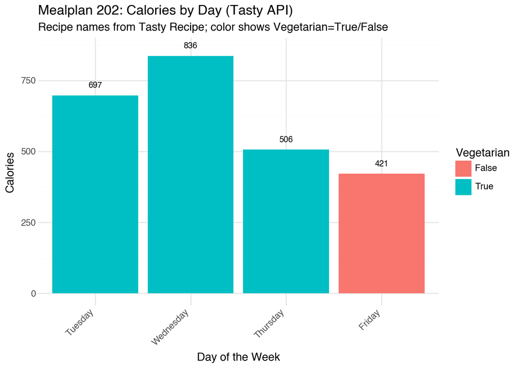

```python
from plotnine import *
plot = (
    ggplot(plot_df, aes(x="Day", y="calories", fill="Vegetarian"))
    + geom_col()
    + geom_text(aes(label="cal_lab"), va="bottom", nudge_y=20, size=8)
    + labs(
        title="Mealplan 202: Calories by Day (Tasty API)",
        subtitle=f"Recipe names from {names}; color shows Vegetarian=True/False",
        x="Day of the Week",
        y="Calories"
    )
    + theme_minimal()
    + theme(axis_text_x=element_text(angle=45, ha="right"))
)
plot
```